# Loan Data (from Prosper) Exploration

## What is/are the main feature(s) of interest in your dataset?

I don't know now but I expect to find out what features can explain loans interest.

What factors affect a loan’s outcome status?

What affects the borrower’s APR or interest rate?

Are there differences between loans depending on how large the original loan amount was?

## Preliminary Wrangling

This data set contains 113,937 loans with 81 variables on each loan, including loan amount, borrower rate (or interest rate), current loan status, borrower income, and many others.

- This data dictionary explains the variables in the data set.
- You are not expected to explore all of the variables in the dataset! Focus your exploration on about 10-15 of them.

### The most contracted loan `Term`

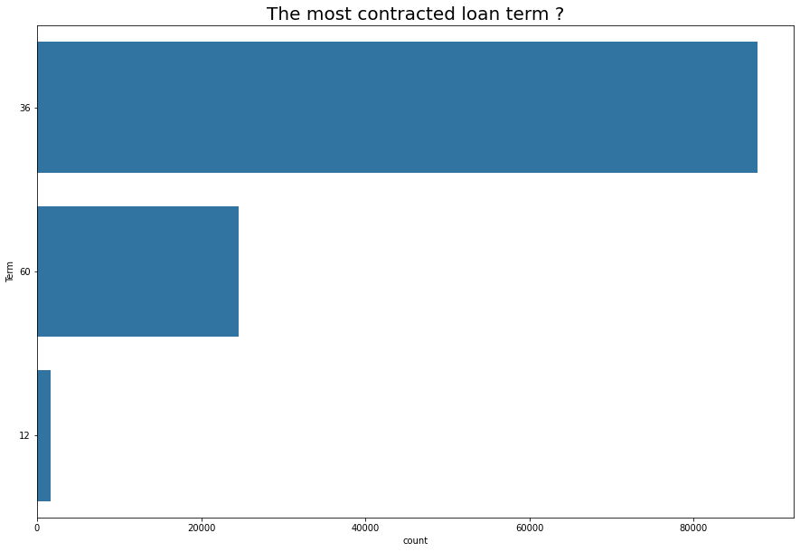

The most contracted loan term is the length of `36 months` with more than 80000 contracts.

### `BorrowerAPR` distribution

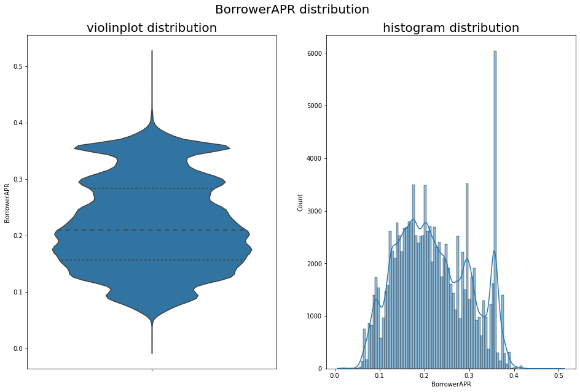

- The distribution is slightly normal
- With a standard deviation of `0.080364` the median value of the BorrowerAPR is `0.209760` and it is closest to the mean `0.218828`. It means that the BorrowerAPR is really good for loans.

### `ProsperRating` distribution

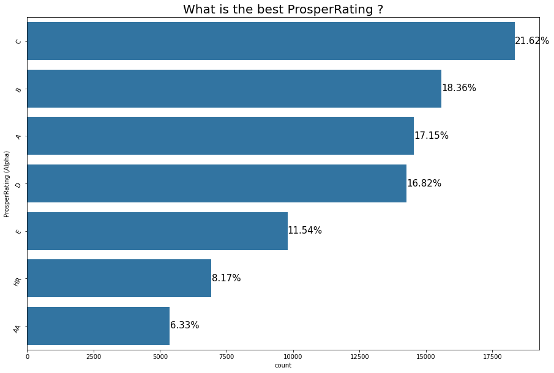

The best ProsperRating is

- The grade `C` is the most represented with `21.62%` and followed by
- The grade `B` is the second most represented with `18.36%` and followed by
- The grade `A` is the third most represented with `17.15%`

### `ListingCategory` distribution

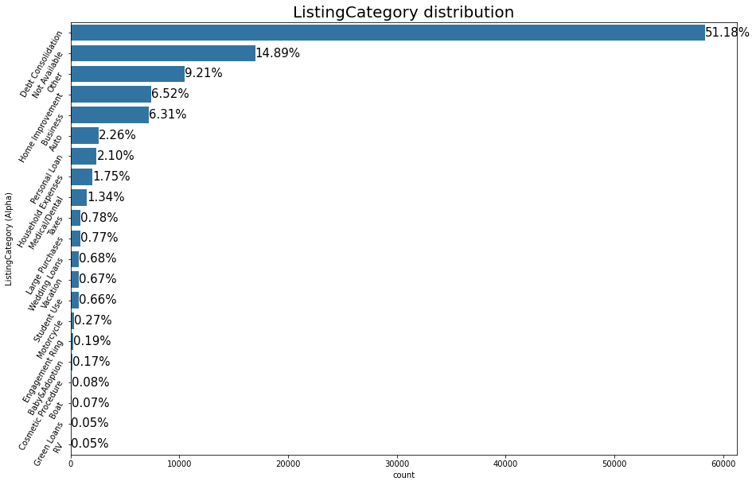

Most of the loans are for `Debt Consolidation`. Really inspiring.

### `Investors` distribution

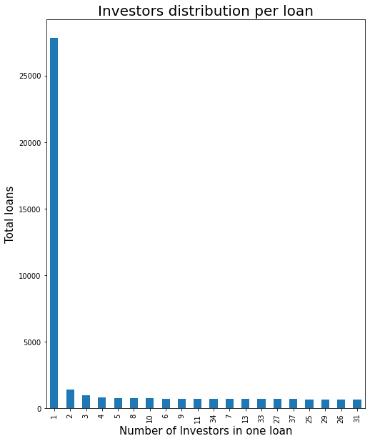

### `EmploymentStatus`, `Occupation`, `EmploymentStatusDuration` and `IsBorrowerHomeowner` distribution

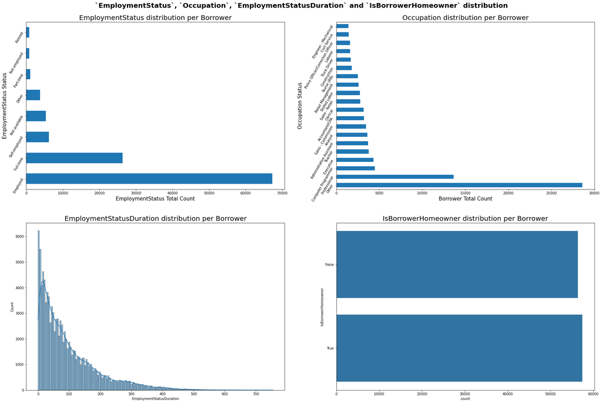

- Most of the Borrowers are employed(Employed, Full-time or Self-employed)
- Most of the Borrowers don't specify their Occupations.
  - More than `10000` Borrowers are `Professionals`
  - Around `5000` Borrowers are `Computer Programmer` and `Executive`
  - Around `4000` Borrowers are `Teacher`, `Administrative Assistant` and `Analyst`
- Around `50%` of Borrowers are either Homeowners or not Homeowners.
- Looks like there needs to be an employee for some time (about 100 months) in order to the a borrower, assuming your employement comes with high revenues. (to be able to be Homeowner.)

### Relationship between `LoanOriginalAmount` and `BorrowerAPR` per `ProsperRating (Alpha)` per `IncomeRange`

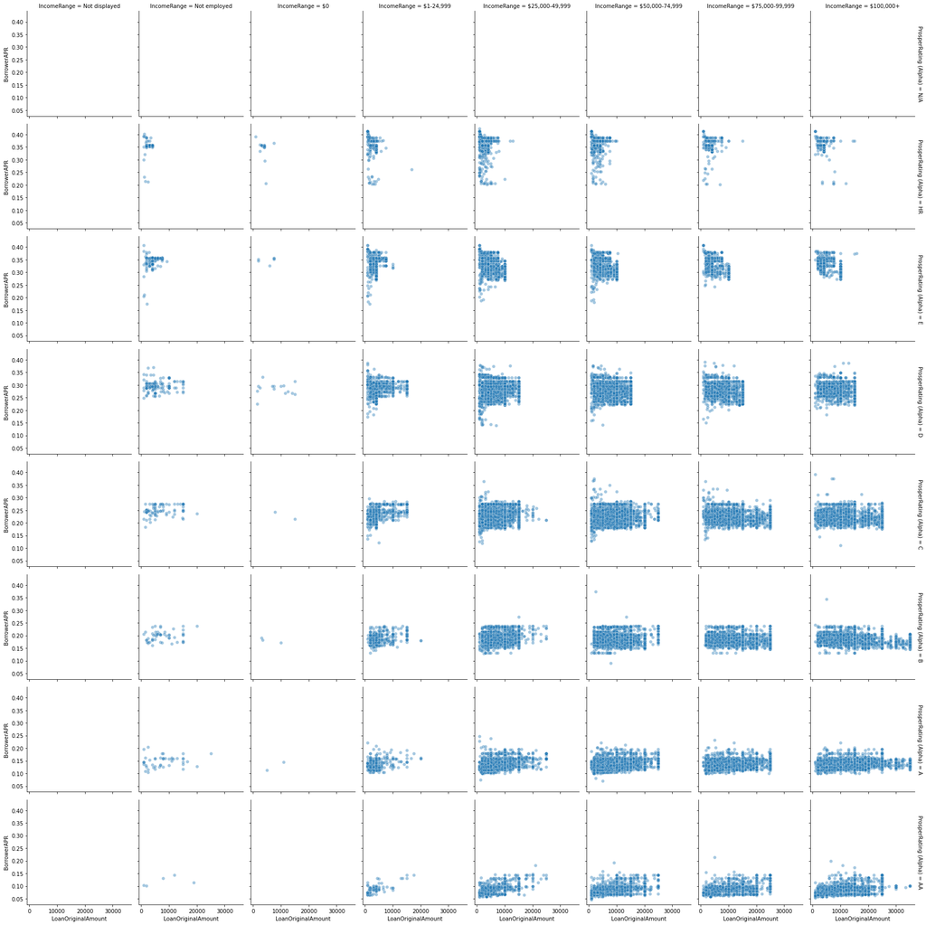

- For `IncomeRange ='Not employed'` it is really difficult to have loan with even a little amount`LoanOriginalAmount` , with even a lower `ProsperRating (Alpha)` score
- For `'IncomeRange =$0'` it is merely impossible to have a loan no matter the `ProsperRating (Alpha)` score
- The `BorrowerAPR` range tend to be lower when the `IncomeRange` tend to be higher and the `ProsperRating (Alpha)` score higher
- The `LoanOriginalAmount` range tend to be higher when the `IncomeRange` tend to be higher and the `ProsperRating (Alpha)` score higher

## Feedback

Thank you for paying attention to my work. Please I need your review to improve myself.

- What do you notice about each visualization?
- What questions do you have about the data?
- What relationships do you notice?
- What do you think is the main takeaway from the report / presentation?
- Is there anything that you don’t understand from the plots?

Kindly reach me:

- LinkedIn : [jozias-tema](https://www.linkedin.com/in/jozias-tema-496a1523a/)
- GitHub : [jozias-tema](https://github.com/temajozias/)
- Gmail : jozias-tema temajozias@gmail.com